# COVID Dashboard data exploration

This notebook will be used for two functions:

1. To download and assess the quality of the datasets, and to decide how to wrangle and clean them.
2. To explore the cleaned data sets.

The actual cleaning of the data sets will be handled in the `data_cleaning.R` file.

#__________________________________ # 1. INSTALL & LOAD LIBRARIES ##### #__________________________________

#________________________________ # 2.DOWNLOAD & LOAD DATA ##### #________________________________

```r
# Ensure the `data_raw` directory exists
if (!dir.exists("data_raw")) {
  dir.create("data_raw")
}
```

```r
# Define the URLs for the CSV files
urls <- list(
  "total_cases_by_health_board" = "https://www.opendata.nhs.scot/dataset/b318bddf-a4dc-4262-971f-0ba329e09b87/resource/7fad90e5-6f19-455b-bc07-694a22f8d5dc/download/total_cases_by_hb_20231004.csv",
  "total_cases_by_local_authority" = "https://www.opendata.nhs.scot/dataset/b318bddf-a4dc-4262-971f-0ba329e09b87/resource/e8454cf0-1152-4bcb-b9da-4343f625dfef/download/total_cases_by_la_20231004.csv",
  "total_cases_by_age_sex" = "https://www.opendata.nhs.scot/dataset/b318bddf-a4dc-4262-971f-0ba329e09b87/resource/19646dce-d830-4ee0-a0a9-fcec79b5ac71/download/total_cases_agesex_20231004.csv",
  "total_cases_by_deprivation" = "https://www.opendata.nhs.scot/dataset/b318bddf-a4dc-4262-971f-0ba329e09b87/resource/a965ee86-0974-4c93-bbea-e839e27d7085/download/total_cases_simd_20231004.csv",
  "daily_case_trends_by_health_board" = "https://www.opendata.nhs.scot/dataset/b318bddf-a4dc-4262-971f-0ba329e09b87/resource/2dd8534b-0a6f-4744-9253-9565d62f96c2/download/trend_hb_20231004.csv",
  "daily_case_trends_by_local_authority" = "https://www.opendata.nhs.scot/dataset/b318bddf-a4dc-4262-971f-0ba329e09b87/resource/427f9a25-db22-4014-a3bc-893b68243055/download/trend_ca_20231004.csv",
  "daily_case_trends_by_age_sex" = "https://www.opendata.nhs.scot/dataset/b318bddf-a4dc-4262-971f-0ba329e09b87/resource/9393bd66-5012-4f01-9bc5-e7a10accacf4/download/trend_agesex_20231004.csv",
  "daily_case_trends_by_deprivation" = "https://www.opendata.nhs.scot/dataset/b318bddf-a4dc-4262-971f-0ba329e09b87/resource/a38a4c21-7c75-4ecd-a511-3f83e0e8f0c3/download/trend_simd_20231004.csv",
  "tests_by_health_board" = "https://www.opendata.nhs.scot/dataset/b318bddf-a4dc-4262-971f-0ba329e09b87/resource/8da654cd-293b-4286-96a4-b3ece86225f0/download/test_hb_20231004.csv",
  "tests_by_local_authority" = "https://www.opendata.nhs.scot/dataset/b318bddf-a4dc-4262-971f-0ba329e09b87/resource/3349540e-dc63-4d6d-a78b-00387b9aca50/download/test_ca_20231004.csv",
  "daily_covid_hospital_admissions" = "https://www.opendata.nhs.scot/dataset/b318bddf-a4dc-4262-971f-0ba329e09b87/resource/bb4d083b-7b92-4722-85a3-a9b58af1f794/download/daily_covid_admissions_20231004.csv",
  "ethnicity" = "https://www.opendata.nhs.scot/dataset/b318bddf-a4dc-4262-971f-0ba329e09b87/resource/07b3dff7-3254-4d26-946f-6cd9ff276a1d/download/ethnicity_20231004.csv",
  "council_area_2019" = "https://www.opendata.nhs.scot/dataset/9f942fdb-e59e-44f5-b534-d6e17229cc7b/resource/967937c4-8d67-4f39-974f-fd58c4acfda5/download/ca11_ca19.csv",
  "statistical_qualifiers" = "https://www.opendata.nhs.scot/dataset/2b6f00ec-fee3-4828-9303-89f31b436d2a/resource/b80f9af0-b115-4245-b591-fb22775226c4/download/statisticalqualifiers24052019.csv",
  "ca_pop_est" = "https://www.opendata.nhs.scot/dataset/7f010430-6ce1-4813-b25c-f7f335bdc4dc/resource/09ebfefb-33f4-4f6a-8312-2d14e2b02ace/download/ca2019_pop_est_29012025.csv",
  "hscp_pop_est" = "https://www.opendata.nhs.scot/dataset/7f010430-6ce1-4813-b25c-f7f335bdc4dc/resource/c3a393ce-253b-4c75-82dc-06b1bb5638a3/download/hscp2019_pop_est_29012025.csv",
  "hb_pop_est" = "https://www.opendata.nhs.scot/dataset/7f010430-6ce1-4813-b25c-f7f335bdc4dc/resource/27a72cc8-d6d8-430c-8b4f-3109a9ceadb1/download/hb2019_pop_est_29012025.csv",
  "scotland_pop_proj" = "https://www.opendata.nhs.scot/dataset/9e00b589-817e-45e6-b615-46c935bbace0/resource/7a9e74c9-8746-488b-8fba-0fad7c7866ea/download/scotland_pop_proj_05022025.csv",
  "ca_pop_proj" = "https://www.opendata.nhs.scot/dataset/9e00b589-817e-45e6-b615-46c935bbace0/resource/63d8e0b9-32e2-4847-9353-177f8d931c10/download/ca_pop_proj_03072020.csv",
  "hscp_pop_proj" = "https://www.opendata.nhs.scot/dataset/9e00b589-817e-45e6-b615-46c935bbace0/resource/93137613-2f5c-4d8f-b756-0432abb6fbc0/download/hscp_pop_proj_03072020.csv",
  "hb_pop_proj" = "https://www.opendata.nhs.scot/dataset/9e00b589-817e-45e6-b615-46c935bbace0/resource/0876fc67-05e6-4e87-bc30-c4b0756fff04/download/hb_pop_proj_03072020.csv",
  "hospital_locations" = "https://www.opendata.nhs.scot/dataset/cbd1802e-0e04-4282-88eb-d7bdcfb120f0/resource/c698f450-eeed-41a0-88f7-c1e40a568acc/download/hospitals.csv"
  )
```

```r
# Download the files if they don't already exist
for (name in names(urls)) {
  file_path <- paste0("data_raw/", name, ".csv")
  if (!file.exists(file_path)) {
    download.file(urls[[name]], file_path)
    message(paste(name, "downloaded successfully."))
  } else {
    message(paste(name, "already exists. Skipping download."))
  }
}
```

```
total_cases_by_health_board already exists. Skipping download.
total_cases_by_local_authority already exists. Skipping download.
total_cases_by_age_sex already exists. Skipping download.
total_cases_by_deprivation already exists. Skipping download.
daily_case_trends_by_health_board already exists. Skipping download.
daily_case_trends_by_local_authority already exists. Skipping download.
daily_case_trends_by_age_sex already exists. Skipping download.
daily_case_trends_by_deprivation already exists. Skipping download.
tests_by_health_board already exists. Skipping download.
tests_by_local_authority already exists. Skipping download.
daily_covid_hospital_admissions already exists. Skipping download.
ethnicity already exists. Skipping download.

council_area_2019 downloaded successfully.

statistical_qualifiers downloaded successfully.

ca_pop_est downloaded successfully.

hscp_pop_est downloaded successfully.

hb_pop_est downloaded successfully.

scotland_pop_proj downloaded successfully.

ca_pop_proj downloaded successfully.

hscp_pop_proj downloaded successfully.

hb_pop_proj downloaded successfully.

hospital_locations downloaded successfully.
```

#____________________________________ # 3. ASSESS DATASETS - BASICS ##### #____________________________________ The following code can be copied and pasted and then adapted as I explore each dataset. These are the fundamental tools I use to explore a dataset.

## ## Initial look at dataset

```r
str(daily_case_trends_by_age_sex)
```

```
spc_tbl_ [43,066 × 26] (S3: spec_tbl_df/tbl_df/tbl/data.frame)
 $ date                           : Date[1:43066], format: "2020-02-28" "2020-02-28" "2020-02-28" "2020-02-28" ...
 $ country                        : chr [1:43066] "S92000003" "S92000003" "S92000003" "S92000003" ...
 $ sex                            : chr [1:43066] "male" "male" "male" "total" ...
 $ sex_qf                         : chr [1:43066] NA NA NA "d" ...
 $ age_group                      : chr [1:43066] "0_to_59" "45_to_64" "total" "0_to_59" ...
 $ age_group_qf                   : chr [1:43066] NA NA "d" NA ...
 $ daily_positive                 : num [1:43066] 1 1 1 1 1 1 0 0 0 0 ...
 $ cumulative_positive            : num [1:43066] 1 1 1 1 1 1 1 1 1 1 ...
 $ daily_deaths                   : num [1:43066] 0 0 0 0 0 0 0 0 0 0 ...
 $ daily_deaths_qf                : chr [1:43066] NA NA NA NA ...
 $ cumulative_deaths              : num [1:43066] 0 0 0 0 0 0 0 0 0 0 ...
 $ cumulative_deaths_qf           : chr [1:43066] NA NA NA NA ...
 $ crude_rate_deaths              : num [1:43066] 0 0 0 0 0 0 0 0 0 0 ...
 $ crude_rate_deaths_qf           : chr [1:43066] NA NA NA NA ...
 $ first_infections               : num [1:43066] 1 1 1 1 1 1 0 0 0 0 ...
 $ first_infections_cumulative    : num [1:43066] 1 1 1 1 1 1 1 1 1 1 ...
 $ reinfections                   : num [1:43066] 0 0 0 0 0 0 0 0 0 0 ...
 $ reinfections_cumulative        : num [1:43066] 0 0 0 0 0 0 0 0 0 0 ...
 $ percent_reinfections           : num [1:43066] 0 0 0 0 0 0 NA NA NA NA ...
 $ percent_reinfections_cumulative: num [1:43066] 0 0 0 0 0 0 0 0 0 0 ...
 $ year                           : num [1:43066] 2020 2020 2020 2020 2020 2020 2020 2020 2020 2020 ...
 $ month                          : num [1:43066] 2 2 2 2 2 2 2 2 2 2 ...
 $ day                            : num [1:43066] 28 28 28 28 28 28 29 29 29 29 ...
 $ week                           : num [1:43066] 9 9 9 9 9 9 9 9 9 9 ...
 $ weekday                        : chr [1:43066] "Fri" "Fri" "Fri" "Fri" ...
 $ season                         : chr [1:43066] "winter" "winter" "winter" "winter" ...
 - attr(*, "spec")=
  .. cols(
  ..   date = col_date(format = ""),
  ..   country = col_character(),
  ..   sex = col_character(),
  ..   sex_qf = col_character(),
  ..   age_group = col_character(),
  ..   age_group_qf = col_character(),
  ..   daily_positive = col_double(),
  ..   cumulative_positive = col_double(),
  ..   daily_deaths = col_double(),
  ..   daily_deaths_qf = col_character(),
  ..   cumulative_deaths = col_double(),
  ..   cumulative_deaths_qf = col_character(),
  ..   crude_rate_deaths = col_double(),
  ..   crude_rate_deaths_qf = col_character(),
  ..   first_infections = col_double(),
  ..   first_infections_cumulative = col_double(),
  ..   reinfections = col_double(),
  ..   reinfections_cumulative = col_double(),
  ..   percent_reinfections = col_double(),
  ..   percent_reinfections_cumulative = col_double(),
  ..   year = col_double(),
  ..   month = col_double(),
  ..   day = col_double(),
  ..   week = col_double(),
  ..   weekday = col_character(),
  ..   season = col_character()
  .. )
 - attr(*, "problems")=<externalptr>
```

- `total_cases_by_local_authority`: New reported daily and cumulative counts and rates for positive COVID-19 cases, negative tests and deaths at Council area (local authority) level.
  - Date - [Date] - can use lubridate to separate into more manageable variables (year, month, day, period)
  - CA - [chr] - Council Area - gives a code eg “S12000006” , that can be linked to CAName - also found in `hospital_locations`.
  - CAName - [chr] - Council Area Name - gives a name eg “Clackmannashire” , that can be linked to CA`.
  - NewPositive : num [1:32] 7 45 31 37 20 7 20 64 21 16 …
  - AverageDailyPositive7Days : num [1:32] 1 6.43 4.43 5.29 2.86 …
  - TotalCases : num [1:32] 22409 50863 54624 42488 42986 …
  - CrudeRatePositive : num [1:32] 43691 34300 44921 39377 44749 …
  - TotalPCROnly : num [1:32] 15472 32453 37242 27022 29642 …
  - AverageDailyPCROnly7Days : num [1:32] 0.286 3 2.286 1.857 1.429 …
  - TotalLFDOnly : num [1:32] 5179 14311 13588 12340 10919 …
  - AverageDailyLFDOnly7Days : num [1:32] 0.714 3.429 2.143 3.429 1.429 …
  - TotalLFDAndPCR : num [1:32] 1758 4099 3794 3126 2425 …
  - AverageDailyLFDAndPCR7Days : num [1:32] NA NA NA NA NA NA NA NA NA NA …
  - FirstInfections : num [1:32] 20537 47615 49596 39466 39554 …
  - AverageDailyFirstInfections7Days : num [1:32] 0.714 4.429 3.143 2.857 1.571 …
  - Reinfections : num [1:32] 1872 3248 5028 3022 3432 …
  - AverageDailyReinfections7Days : num [1:32] 0.286 2 1.286 2.429 1.286 …
  - PercentReinfections : num [1:32] 8.35 6.39 9.2 7.11 7.98 …
  - AverageDailyPercentReinfections7Days: num [1:32] 28.6 31.1 29 45.9 45 …
- `total_cases_by_health_board`:
- `total_cases_by_deprivation`:
- `total_cases_by_age_sex`:
- `tests_by_local_authority`:
- `tests_by_health_board`:
- `hospital_location`:
- `ethnicity`:
- `daily_covid_hospital_admissions`:
- `daily_case_trends_by_local_authority`:
- `daily_case_trends_by_health_board`:
- `daily_case_trends_by_deprivation`:
- `daily_case_trends_by_age_sex`:

```r
summary(hospital_location)
```

```
       id        location         location_name        postcode         address_line            hb                hscp
 Min.   :  1   Length:277         Length:277         Length:277         Length:277         Length:277         Length:277
 1st Qu.: 70   Class :character   Class :character   Class :character   Class :character   Class :character   Class :character
 Median :139   Mode  :character   Mode  :character   Mode  :character   Mode  :character   Mode  :character   Mode  :character
 Mean   :139
 3rd Qu.:208
 Max.   :277

    hscpqf               ca                caqf             int_zone         int_zone_qf         data_zone         data_zone_qf
 Length:277         Length:277         Length:277         Length:277         Length:277         Length:277         Length:277
 Class :character   Class :character   Class :character   Class :character   Class :character   Class :character   Class :character
 Mode  :character   Mode  :character   Mode  :character   Mode  :character   Mode  :character   Mode  :character   Mode  :character




  x_coordinate     y_coordinate     based_on_postcode
 Min.   : 65926   Min.   : 550781   Length:277
 1st Qu.:258997   1st Qu.: 658810   Class :character
 Median :297742   Median : 673025   Mode  :character
 Mean   :297190   Mean   : 704545
 3rd Qu.:337803   3rd Qu.: 742178
 Max.   :446981   Max.   :1141029
 NA's   :1        NA's   :1
```

| id | location | location_name | postcode | address_line | hb | hscp | hscpqf | ca | caqf | int_zone | int_zone_qf | data_zone | data_zone_qf | x_coordinate | y_coordinate | based_on_postcode |
| --- | --- | --- | --- | --- | --- | --- | --- | --- | --- | --- | --- | --- | --- | --- | --- | --- |
| 1 | A101H | Arran War Memorial Hospital | KA27 8LF | Lamlash, Isle of Arran | S08000015 | S37000020 | NA | S12000021 | NA | S02002097 | NA | S01011176 | NA | 203533.0 | 632121.0 | NA |
| 2 | A103H | Ayrshire Central Hospital | KA12 8SS | Kilwinning Road, Irvine | S08000015 | S37000020 | NA | S12000021 | NA | S02002105 | NA | S01011213 | NA | 231514.0 | 641144.0 | NA |
| 3 | A105H | Kirklandside Hospital | KA1 5LH | Kirklandside, Kilmarnock, Ayrshire | S08000015 | S37000008 | NA | S12000008 | NA | S02001492 | NA | S01007961 | NA | 244240.0 | 636263.4 | NA |
| 4 | A110H | Lady Margaret Hospital | KA28 0HF | College St, Millport, Isle of Cumbrae | S08000015 | S37000020 | NA | S12000021 | NA | S02002128 | NA | S01011328 | NA | 216713.0 | 655863.0 | NA |
| 5 | A111H | University Hospital Crosshouse | KA2 0BE | Kilmarnock Road, Kilmarnock, Ayrshire | S08000015 | S37000008 | NA | S12000008 | NA | S02001504 | NA | S01008027 | NA | 240159.8 | 638520.4 | NA |
| 6 | A112H | Brooksby Day Hospital | KA30 8NE | 18 Greenock Road, Largs | S08000015 | S37000020 | NA | S12000021 | NA | S02002129 | NA | S01011329 | NA | 220335.0 | 659862.0 | Yes |

## Missing Data

The majority of the missing data are in the qualifier columns, e.g, `hbqf`, `sex_qf`, etc. The qualifier column contains NA values to indicate that no data quality issues were identified for those records. Replacing NA values with 0 or another placeholder would obscure this information and potentially misrepresent the data. Retaining NA values ensures transparency and preserves the integrity of the dataset, allowing for accurate interpretation and analysis.

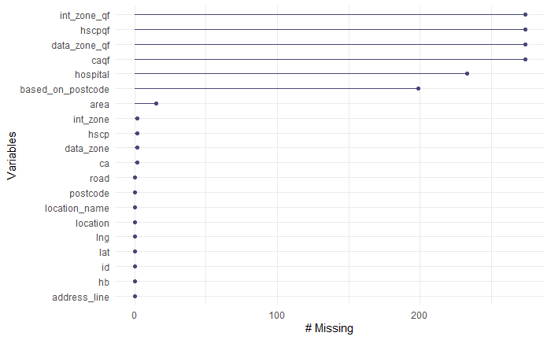

This code is to be used if it becomes necessary to remove NA values from the datasets.

```r
# Handle missing values by replacing with 0
# total_cases_by_local_authority <- total_cases_by_local_authority %>%
#   mutate(across(everything(), ~ifelse(is.na(.), 0, .)))
```

#___________________________________________________________ # 4. DATA EXPLORATION - total_cases_by_health_board ##### #___________________________________________________________

# Check the structure of the dataset str(total_cases_by_health_board)

```r
# Summary statistics
summary(total_cases_by_health_board)
```

```
      date                 ca              ca_name           new_positive    average_daily_positive7days  total_cases
 Min.   :2023-10-03   Length:32          Length:32          Min.   :  2.00   Min.   : 0.2857             Min.   :  6449
 1st Qu.:2023-10-03   Class :character   Class :character   1st Qu.: 20.00   1st Qu.: 2.8571             1st Qu.: 37397
 Median :2023-10-03   Mode  :character   Mode  :character   Median : 32.00   Median : 4.5714             Median : 49939
 Mean   :2023-10-03                                         Mean   : 36.28   Mean   : 5.1830             Mean   : 68315
 3rd Qu.:2023-10-03                                         3rd Qu.: 39.25   3rd Qu.: 5.6071             3rd Qu.: 79856
 Max.   :2023-10-03                                         Max.   :133.00   Max.   :19.0000             Max.   :265583

 crude_rate_positive total_pcr_only   average_daily_pcr_only7days total_lfd_only  average_daily_lfd_only7days total_lfd_and_pcr
 Min.   :28790       Min.   :  2198   Min.   :0.2857              Min.   : 3561   Min.   :0.1429              Min.   :  414
 1st Qu.:34823       1st Qu.: 24150   1st Qu.:1.4286              1st Qu.:10301   1st Qu.:1.4286              1st Qu.: 2478
 Median :39411       Median : 33065   Median :2.0000              Median :12774   Median :2.2857              Median : 3460
 Mean   :39258       Mean   : 45928   Mean   :2.5714              Mean   :17657   Mean   :2.6830              Mean   : 4730
 3rd Qu.:43273       3rd Qu.: 50777   3rd Qu.:3.0714              3rd Qu.:20772   3rd Qu.:3.4286              3rd Qu.: 5766
 Max.   :46119       Max.   :198253   Max.   :9.7143              Max.   :55087   Max.   :9.2857              Max.   :15962
                                      NA's   :1
 average_daily_lfd_and_pcr7days first_infections average_daily_first_infections7days  reinfections   average_daily_reinfections7days
 Min.   :0.00000                Min.   :  6235   Min.   : 0.1429                     Min.   :  214   Min.   :0.0000
 1st Qu.:0.00000                1st Qu.: 35108   1st Qu.: 1.8571                     1st Qu.: 2687   1st Qu.:0.8571
 Median :0.00000                Median : 46289   Median : 2.7857                     Median : 3580   Median :1.6429
 Mean   :0.05714                Mean   : 62964   Mean   : 3.2589                     Mean   : 5351   Mean   :1.9241
 3rd Qu.:0.14286                3rd Qu.: 74781   3rd Qu.: 3.5000                     3rd Qu.: 5321   3rd Qu.:2.4286
 Max.   :0.14286                Max.   :240045   Max.   :10.8571                     Max.   :25538   Max.   :8.1429
 NA's   :27
 percent_reinfections average_daily_percent_reinfections7days
 Min.   :3.318        Min.   : 0.00
 1st Qu.:6.128        1st Qu.:29.76
 Median :7.672        Median :35.90
 Mean   :7.251        Mean   :35.70
 3rd Qu.:8.556        3rd Qu.:43.94
 Max.   :9.635        Max.   :60.61
```

```r
# View the first few rows
head(total_cases_by_health_board)
```

| date | ca | ca_name | new_positive | average_daily_positive7days | total_cases | crude_rate_positive | total_pcr_only | average_daily_pcr_only7days | total_lfd_only | average_daily_lfd_only7days | total_lfd_and_pcr | average_daily_lfd_and_pcr7days | first_infections | average_daily_first_infections7days | reinfections | average_daily_reinfections7days | percent_reinfections | average_daily_percent_reinfections7days |
| --- | --- | --- | --- | --- | --- | --- | --- | --- | --- | --- | --- | --- | --- | --- | --- | --- | --- | --- |
| 2023-10-03 | S12000005 | clackmannanshire | 7 | 1.000000 | 22409 | 43690.78 | 15472 | 0.2857143 | 5179 | 0.7142857 | 1758 | NA | 20537 | 0.7142857 | 1872 | 0.2857143 | 8.353786 | 28.57143 |
| 2023-10-03 | S12000006 | dumfries_and_galloway | 45 | 6.428571 | 50863 | 34299.68 | 32453 | 3.0000000 | 14311 | 3.4285714 | 4099 | NA | 47615 | 4.4285714 | 3248 | 2.0000000 | 6.385781 | 31.11111 |
| 2023-10-03 | S12000008 | east_ayrshire | 31 | 4.428571 | 54624 | 44921.05 | 37242 | 2.2857143 | 13588 | 2.1428571 | 3794 | NA | 49596 | 3.1428571 | 5028 | 1.2857143 | 9.204745 | 29.03226 |
| 2023-10-03 | S12000010 | east_lothian | 37 | 5.285714 | 42488 | 39377.20 | 27022 | 1.8571429 | 12340 | 3.4285714 | 3126 | NA | 39466 | 2.8571429 | 3022 | 2.4285714 | 7.112596 | 45.94595 |
| 2023-10-03 | S12000011 | east_renfrewshire | 20 | 2.857143 | 42986 | 44749.12 | 29642 | 1.4285714 | 10919 | 1.4285714 | 2425 | NA | 39554 | 1.5714286 | 3432 | 1.2857143 | 7.983995 | 45.00000 |
| 2023-10-03 | S12000013 | na_h-eileanan_siar | 7 | 1.000000 | 9249 | 34901.89 | 4169 | 0.8571429 | 3627 | 0.1428571 | 1453 | NA | 8774 | 0.5714286 | 475 | 0.4285714 | 5.135690 | 42.85714 |

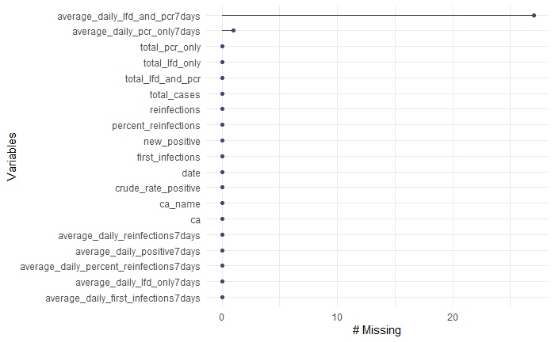

```r
# Visualize missing data
gg_miss_var(total_cases_by_health_board)
```

#______________________________________________________________ # 5. DATA EXPLORATION - total_cases_by_local_authority ##### #______________________________________________________________

# Check the structure of the dataset str(total_cases_by_local_authority)

```r
# Summary statistics
summary(total_cases_by_local_authority)
```

```
      Date                 CA               CAName           NewPositive     AverageDailyPositive7Days   TotalCases     CrudeRatePositive
 Min.   :2023-10-03   Length:32          Length:32          Min.   :  2.00   Min.   : 0.2857           Min.   :  6449   Min.   :28790
 1st Qu.:2023-10-03   Class :character   Class :character   1st Qu.: 20.00   1st Qu.: 2.8571           1st Qu.: 37397   1st Qu.:34823
 Median :2023-10-03   Mode  :character   Mode  :character   Median : 32.00   Median : 4.5714           Median : 49939   Median :39411
 Mean   :2023-10-03                                         Mean   : 36.28   Mean   : 5.1830           Mean   : 68315   Mean   :39258
 3rd Qu.:2023-10-03                                         3rd Qu.: 39.25   3rd Qu.: 5.6071           3rd Qu.: 79856   3rd Qu.:43273
 Max.   :2023-10-03                                         Max.   :133.00   Max.   :19.0000           Max.   :265583   Max.   :46119

  TotalPCROnly    AverageDailyPCROnly7Days  TotalLFDOnly   AverageDailyLFDOnly7Days TotalLFDAndPCR  AverageDailyLFDAndPCR7Days
 Min.   :  2198   Min.   :0.2857           Min.   : 3561   Min.   :0.1429           Min.   :  414   Min.   :0.00000
 1st Qu.: 24150   1st Qu.:1.4286           1st Qu.:10301   1st Qu.:1.4286           1st Qu.: 2478   1st Qu.:0.00000
 Median : 33065   Median :2.0000           Median :12774   Median :2.2857           Median : 3460   Median :0.00000
 Mean   : 45928   Mean   :2.5714           Mean   :17657   Mean   :2.6830           Mean   : 4730   Mean   :0.05714
 3rd Qu.: 50777   3rd Qu.:3.0714           3rd Qu.:20772   3rd Qu.:3.4286           3rd Qu.: 5766   3rd Qu.:0.14286
 Max.   :198253   Max.   :9.7143           Max.   :55087   Max.   :9.2857           Max.   :15962   Max.   :0.14286
                  NA's   :1                                                                         NA's   :27
 FirstInfections  AverageDailyFirstInfections7Days  Reinfections   AverageDailyReinfections7Days PercentReinfections
 Min.   :  6235   Min.   : 0.1429                  Min.   :  214   Min.   :0.0000                Min.   :3.318
 1st Qu.: 35108   1st Qu.: 1.8571                  1st Qu.: 2687   1st Qu.:0.8571                1st Qu.:6.128
 Median : 46289   Median : 2.7857                  Median : 3580   Median :1.6429                Median :7.672
 Mean   : 62964   Mean   : 3.2589                  Mean   : 5351   Mean   :1.9241                Mean   :7.251
 3rd Qu.: 74781   3rd Qu.: 3.5000                  3rd Qu.: 5321   3rd Qu.:2.4286                3rd Qu.:8.556
 Max.   :240045   Max.   :10.8571                  Max.   :25538   Max.   :8.1429                Max.   :9.635

 AverageDailyPercentReinfections7Days
 Min.   : 0.00
 1st Qu.:29.76
 Median :35.90
 Mean   :35.70
 3rd Qu.:43.94
 Max.   :60.61
```

```r
# View the first few rows
head(total_cases_by_local_authority)
```

| Date | CA | CAName | NewPositive | AverageDailyPositive7Days | TotalCases | CrudeRatePositive | TotalPCROnly | AverageDailyPCROnly7Days | TotalLFDOnly | AverageDailyLFDOnly7Days | TotalLFDAndPCR | AverageDailyLFDAndPCR7Days | FirstInfections | AverageDailyFirstInfections7Days | Reinfections | AverageDailyReinfections7Days | PercentReinfections | AverageDailyPercentReinfections7Days |
| --- | --- | --- | --- | --- | --- | --- | --- | --- | --- | --- | --- | --- | --- | --- | --- | --- | --- | --- |
| 2023-10-03 | S12000005 | Clackmannanshire | 7 | 1.000000 | 22409 | 43690.78 | 15472 | 0.2857143 | 5179 | 0.7142857 | 1758 | NA | 20537 | 0.7142857 | 1872 | 0.2857143 | 8.353786 | 28.57143 |
| 2023-10-03 | S12000006 | Dumfries and Galloway | 45 | 6.428571 | 50863 | 34299.68 | 32453 | 3.0000000 | 14311 | 3.4285714 | 4099 | NA | 47615 | 4.4285714 | 3248 | 2.0000000 | 6.385781 | 31.11111 |
| 2023-10-03 | S12000008 | East Ayrshire | 31 | 4.428571 | 54624 | 44921.05 | 37242 | 2.2857143 | 13588 | 2.1428571 | 3794 | NA | 49596 | 3.1428571 | 5028 | 1.2857143 | 9.204745 | 29.03226 |
| 2023-10-03 | S12000010 | East Lothian | 37 | 5.285714 | 42488 | 39377.20 | 27022 | 1.8571429 | 12340 | 3.4285714 | 3126 | NA | 39466 | 2.8571429 | 3022 | 2.4285714 | 7.112596 | 45.94595 |
| 2023-10-03 | S12000011 | East Renfrewshire | 20 | 2.857143 | 42986 | 44749.12 | 29642 | 1.4285714 | 10919 | 1.4285714 | 2425 | NA | 39554 | 1.5714286 | 3432 | 1.2857143 | 7.983995 | 45.00000 |
| 2023-10-03 | S12000013 | Na h-Eileanan Siar | 7 | 1.000000 | 9249 | 34901.89 | 4169 | 0.8571429 | 3627 | 0.1428571 | 1453 | NA | 8774 | 0.5714286 | 475 | 0.4285714 | 5.135690 | 42.85714 |

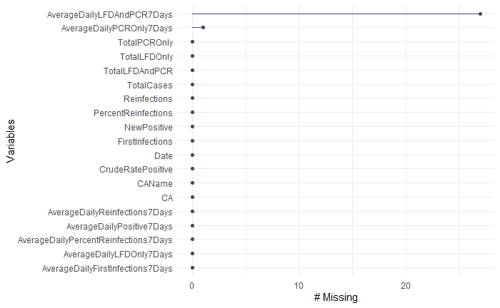

```r
# Visualize missing data
gg_miss_var(total_cases_by_local_authority)
```

#_______________________________________________________________ # 6. DATA EXPLORATION - total_cases_by_age_sex ##### #_______________________________________________________________

total_cases_by_age_sex <- total_cases_by_age_sex %>% mutate(Date = as.Date(as.character(Date), format = “%Y%m%d”))

# Convert Date and create new variables for total_cases_by_age_sex

total_cases_by_age_sex <- total_cases_by_age_sex %>% mutate(Date = ymd(Date), Year = year(Date), Month = month(Date, label = TRUE), Day = day(Date), Week = week(Date), Weekday = wday(Date, label = TRUE))

#___________________________________________________________________ # 7. DATA EXPLORATION - total_cases_by_deprivation ##### #___________________________________________________________________ total_cases_by_deprivation <- total_cases_by_deprivation %>% mutate(Date = as.Date(Date, format = “%Y-%m-%d”))

daily_case_trends_by_health_board <- daily_case_trends_by_health_board %>% mutate(Date = as.Date(Date, format = “%Y-%m-%d”))

#_____________________________________________________________________________ # 8. DATA EXPLORATION - daily_case_trends_by_local_authority ##### #_____________________________________________________________________________ daily_case_trends_by_local_authority <- daily_case_trends_by_local_authority %>% mutate(Date = as.Date(Date, format = “%Y-%m-%d”))

# Convert Date and create new variables for daily_case_trends_by_local_authority

daily_case_trends_by_local_authority <- daily_case_trends_by_local_authority %>% mutate(Date = ymd(Date), Year = year(Date), Month = month(Date, label = TRUE), Day = day(Date), Week = week(Date), Weekday = wday(Date, label = TRUE))

#______________________________________________________________________ # 9. DATA EXPLORATION - daily_case_trends_by_age_sex ##### #______________________________________________________________________

daily_case_trends_by_age_sex <- daily_case_trends_by_age_sex %>% mutate(Date = as.Date(as.character(Date), format = “%Y%m%d”))

# Convert Date and create new variables for daily_case_trends_by_age_sex

daily_case_trends_by_age_sex <- daily_case_trends_by_age_sex %>% mutate(Date = ymd(Date), Year = year(Date), Month = month(Date, label = TRUE), Day = day(Date), Week = week(Date), Weekday = wday(Date, label = TRUE))

#___________________________________________________________________________ # 10. DATA EXPLORATION - daily_case_trends_by_deprivation ##### #___________________________________________________________________________

daily_case_trends_by_deprivation <- daily_case_trends_by_deprivation %>% mutate(Date = as.Date(Date, format = “%Y-%m-%d”))

# Convert Date and create new variables for daily_case_trends_by_deprivation

daily_case_trends_by_deprivation <- daily_case_trends_by_deprivation %>% mutate(Date = ymd(Date), Year = year(Date), Month = month(Date, label = TRUE), Day = day(Date), Week = week(Date), Weekday = wday(Date, label = TRUE))

#_______________________________________________________________ # 11. DATA EXPLORATION - tests_by_health_board ##### #_______________________________________________________________ tests_by_health_board <- tests_by_health_board %>% mutate(Date = as.Date(Date, format = “%Y-%m-%d”))

# Convert Date and create new variables for tests_by_health_board

tests_by_health_board <- tests_by_health_board %>% mutate(Date = ymd(Date), Year = year(Date), Month = month(Date, label = TRUE), Day = day(Date), Week = week(Date), Weekday = wday(Date, label = TRUE))

#__________________________________________________________________ # 12. DATA EXPLORATION - tests_by_local_authority ##### #__________________________________________________________________

tests_by_local_authority <- tests_by_local_authority %>% mutate(Date = as.Date(Date, format = “%Y-%m-%d”))

# Convert Date and create new variables for tests_by_local_authority

tests_by_local_authority <- tests_by_local_authority %>% mutate(Date = ymd(Date), Year = year(Date), Month = month(Date, label = TRUE), Day = day(Date), Week = week(Date), Weekday = wday(Date, label = TRUE))

#_________________________________________________________________________ # 13. DATA EXPLORATION - daily_covid_hospital_admissions ##### #_________________________________________________________________________

daily_covid_hospital_admissions <- daily_covid_hospital_admissions %>% mutate(Date = as.Date(Date, format = “%Y-%m-%d”))

daily_covid_hospital_admissions <- daily_covid_hospital_admissions %>% mutate(Date = ymd(Date), Year = year(Date), Month = month(Date, label = TRUE), Day = day(Date), Week = week(Date), Weekday = wday(Date, label = TRUE))

#___________________________________________________ # 14. DATA EXPLORATION - ethnicity ##### #___________________________________________________

ethnicity <- ethnicity %>% mutate(Date = ymd(Date), Year = year(Date), Month = month(Date, label = TRUE), Day = day(Date), Week = week(Date), Weekday = wday(Date, label = TRUE))

#___________________________________________________________ # 15. DATA EXPLORATION - hospital_location ##### #___________________________________________________________

```r
non_numeric_lng <- !is.numeric(hospital_location$lng)
non_numeric_lat <- !is.numeric(hospital_location$lat)
```

```r
blank_lng <- hospital_location$lng == ""
blank_lat <- hospital_location$lat == ""
print(hospital_location[blank_lng | blank_lat, ])
```

| id | location | location_name | postcode | address_line | hb | hscp | hscpqf | ca | caqf | int_zone | int_zone_qf | data_zone | data_zone_qf | based_on_postcode | hospital | road | area | lng | lat |
| --- | --- | --- | --- | --- | --- | --- | --- | --- | --- | --- | --- | --- | --- | --- | --- | --- | --- | --- | --- |

```r
hospital_location$lng <- trimws(hospital_location$lng)
hospital_location$lat <- trimws(hospital_location$lat)
```